# 14_half_life_from_graph

## 14_half_life_from_graph

#### Question

1. The [half-life](https://en.wikipedia.org/wiki/Half-life) of an exponentially decaying function is the amount of time it takes for the population to halve.

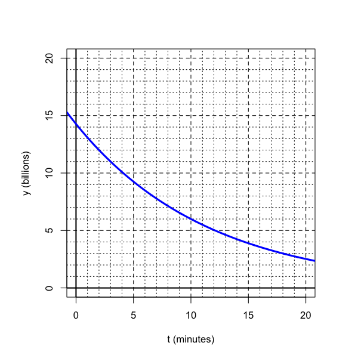

   What is the half-life (in minutes) of the exponential function graphed above? (The answer is an integer.)

#### Question

2. The [half-life](https://en.wikipedia.org/wiki/Half-life) of an exponentially decaying function is the amount of time it takes for the population to halve.

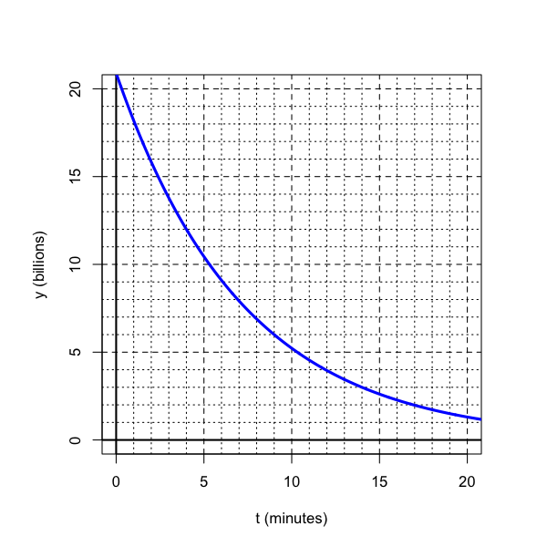

   What is the half-life (in minutes) of the exponential function graphed above? (The answer is an integer.)

#### Question

3. The [half-life](https://en.wikipedia.org/wiki/Half-life) of an exponentially decaying function is the amount of time it takes for the population to halve.

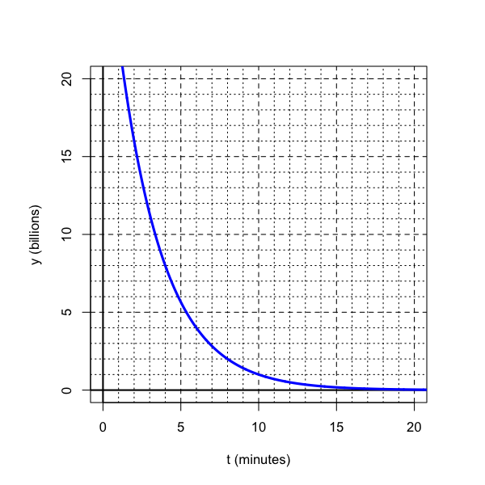

   What is the half-life (in minutes) of the exponential function graphed above? (The answer is an integer.)

#### Question

4. The [half-life](https://en.wikipedia.org/wiki/Half-life) of an exponentially decaying function is the amount of time it takes for the population to halve.

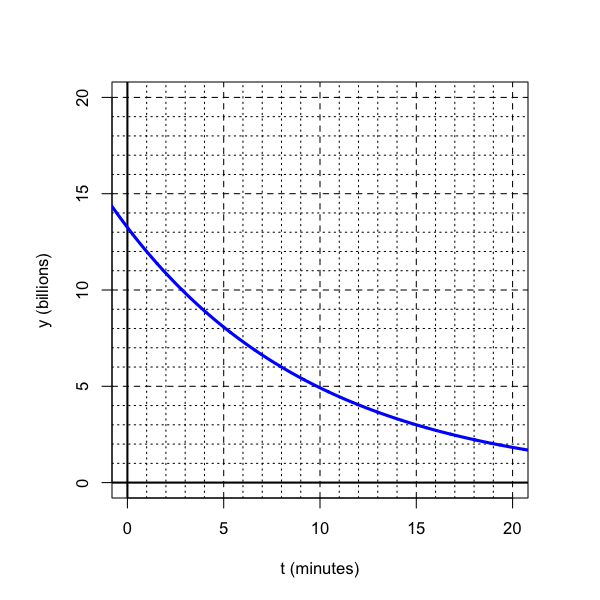

   What is the half-life (in minutes) of the exponential function graphed above? (The answer is an integer.)

#### Question

5. The [half-life](https://en.wikipedia.org/wiki/Half-life) of an exponentially decaying function is the amount of time it takes for the population to halve.

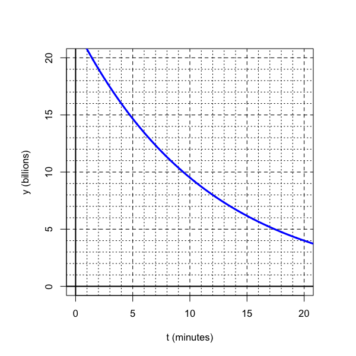

   What is the half-life (in minutes) of the exponential function graphed above? (The answer is an integer.)

#### Question

6. The [half-life](https://en.wikipedia.org/wiki/Half-life) of an exponentially decaying function is the amount of time it takes for the population to halve.

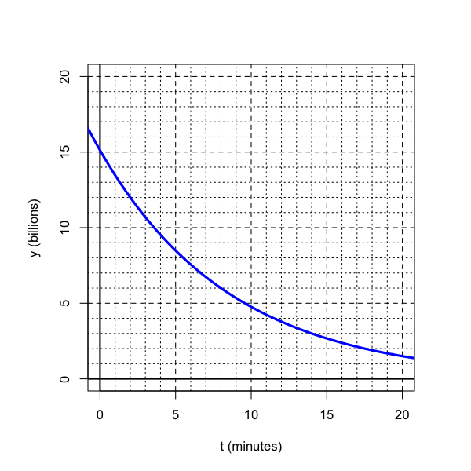

   What is the half-life (in minutes) of the exponential function graphed above? (The answer is an integer.)

#### Question

7. The [half-life](https://en.wikipedia.org/wiki/Half-life) of an exponentially decaying function is the amount of time it takes for the population to halve.

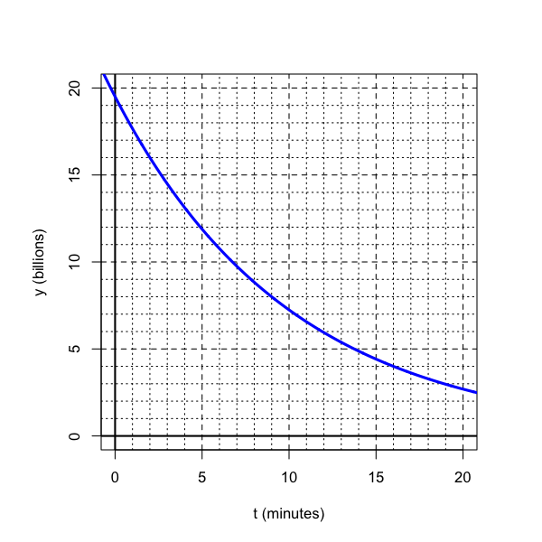

   What is the half-life (in minutes) of the exponential function graphed above? (The answer is an integer.)

#### Question

8. The [half-life](https://en.wikipedia.org/wiki/Half-life) of an exponentially decaying function is the amount of time it takes for the population to halve.

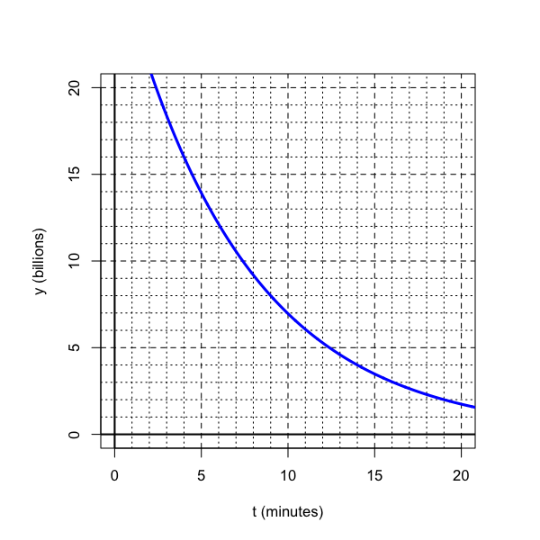

   What is the half-life (in minutes) of the exponential function graphed above? (The answer is an integer.)